# Analysis of ‘but not both’ experiment

jdegen

Dec 14, 2017

## Goal

Figure out, for each case, whether it’s worth running it in the scalar implicature experiment (ie, analogous to the “some” paper, comparing original sentence to one with potentially implicated content locally explicit).

## To determine

What is the best “but not both” sentence selection criterion, of the three we have? Neele’s initial pilot analysis suggested that the modal response was best for 25 of 30 sentences. In general: the modal response seems best for cases that receive only few different responses. For cases with more diversity in responses, selecting the case with the greatest proportion of “good location” responses seems to work best.

Questions that need to be answered:

1. Is it even worth running sentences with too low of a proportion of “good location” responses? What is a reasonable cutoff point for proportion of “good location” responses?
2. What is the cutoff point for number of different lcoations of “but not both” above which we should deviate from the modal response selection method?
3. Which cases need to be looked at manually, if any?

Selection criteria:

1. **Include** cases where all three response selection methods yield the same result and **select modal response**.
2. **Exclude** cases with lower than XXX (10-20%)% “good location” responses. (If 1. and 2. are in conflict, include or exclude? Hand-check some responses to come up with general rule)
3. **Include** cases with higher than XXX (70-80)% “good location” responses. If selection methods are in conflict:
- if fewer than (3(oder2))XXX different responses were generated, **select modal response**
- if more than (3)XXX different responses were generated, **exclude**
- else, **select proportion response**

## Columns

- **tgrep.id/TGrepID:** unique TGrep2 ID
- **entire.sentence/EntireSentence:** original sentence, without ‘but not both’ insertion
- **Num_different_BNBForms/NumBNBForms**: number of different locations for “but not both” that were generated
- **Proportion_goodLoc_perBNB/PropGoodLocation:** proportion of participants that rated the case as having a good location for “but not both” – Neele, what is “the case” here? Ie if modal response etc differ, what does this column code?
- **modal_response/ResponseModal:** the most frequently given response
- **ResponseFreqGoodLocation/ResponseFreqGoodLocation:** the response with greatest frequency of “good location” responses
- **ResponsePropGoodLocation/ResponsePropGoodLocation:** the response with greatest proportion of “good location” responses
- **SentenceOverlap/SentenceOverlap:** do all three methods for selecting the best response yield the same result?
- **MoreThanOneModalResponse/MoreThanOneModalResponse**: are there more than one BNB Sentences that are most frequent? -**MoreThanOneFreqResponse/MoreThanOneFreqResponse**: are there more than one BNB Sentences with most frequency of “good location” responses? -**MoreThanOnePropResponse/MoreThanOnePropResponse**: are there more than one BNB Sentences with greates proportion of “good location” responses? -**ResponseBNBClosestToOrModal/ResponseBNBClosestToOrModal**: if MoreThanOneModalResponse is True, this encodes the most frequent BNB Sentence where or is closer to but not both, but not directly followed by it. -**ResponseBNBClosestToOrFreq/ResponseBNBClosestToOrFreq**: if MoreThanOneFreqResponse is True, this encodes the BNB Sentence with most frequent “good location” responses where or is closer to but not both, but not directly followed by it. **-ResponseBNBClosestToOrProp/ResponseBNBClosestToOrProp**: if MoreThanOnePropResponse is True, this encodes the BNB Sentence with highest proportion of “good location” responses where or is closer to but not both, but not directly followed by it. **-BestResponse**: This will encode the best BNB Sentence, extracted by evaluatin different criteria

Load packages, read the data, rename columns, compute sentence length (will be twice as long for sentences with two best responses), create an empty new column with final sentence to use.

```r
library(tidyverse)
library(knitr)
d = read.table("../data/newfinal2.csv",header=T,sep="\t",quote="")
colnames(d) = c("TGrepID","EntireSentence","NumBNBForms","PropGoodLocation","ResponseModal","ResponseFreqGoodLocation","ResponsePropGoodLocation","SentenceOverlap", "BNCClosestToOr")
d$SentenceLength = nchar(as.character(d$EntireSentence))
d$BestResponse = ""
```

There are 1244 cases.

## Selection process

### **Include** cases where all three response selection methods yield the same result and **select modal response**.

In about half (610) of the cases the same “but not both” sentence is chosen regardless of choice criterion. Some of those sentences:

```r
d[d$SentenceOverlap == T,]$BestResponse = as.character(d[d$SentenceOverlap == T,]$ResponseModal)
table(d$SentenceOverlap)
```

```
##
## FALSE  TRUE
##   634   610
```

```r
sample(d[d$SentenceOverlap == T,]$ResponseModal,5)
```

```
## [1] and they had  to kick. and, uh,  to know whether we were going  to win the game or lose a game but not both because they got one point ahead of us.
## [2] it kind of reminds me of  using an a t m card, you know,  to get money or doing your banking but not both.
## [3] and so i'm just grateful that we don't have  to worry so much about my working or not but not both.
## [4] you know, i saw something  on c n n or on cable here a while ago that  showed some people that  had rabbits in apartments and in houses but not both,
## [5] if we paid them more, it would attract more the, the higher educated people to, to either move into that field or to continue in that field but not both.
## 1244 Levels: --ing seems  to be a, a topic that 's going  to probably take about a generation   to, uh, catch on, it seems , or maybe a generation to two but not both.  ...
```

Problem: there appear to be a number of cases where the modal response contains more than 2 responses, even among cases that have overlap in all three measures.

```r
# table(d$SentenceOverlap,d$MoreThanOneModalResponse)
```

Let’s look at the 0 cases with overlap that nevertheless include more than one response – what should we do with these?

```r
# d[d$SentenceOverlap & d$MoreThanOneModalResponse,]$ResponseModal
```

**Decision:** In each of these cases, include the one with ‘but not both’ earlier in the sentence (ie closer to ‘or’). Neele, add code that extracts these in addition to this line of code that just extracts the modal response for the ones with complete overlap and only one best response:

```r
# target = which(d$SentenceOverlap==TRUE & d$MoreThanOneModalResponse==TRUE)
#
# for (index in 1:nrow(d[d$SentenceOverlap & d$MoreThanOneModalResponse,])){
#   dataindex = target[index]
#   finalbnb = d[dataindex,]$ResponseBNBClosestToOrModal
#   d$BestResponse[dataindex]=finalbnb
# }
# write.csv(d, file="../data/bestresponses.csv")
```

### **Exclude** cases with lower than XXX (10-20%)% “good location” responses.

For the cases that don’t include the already included cases from 1, what is the distribution of proportion of good locations?

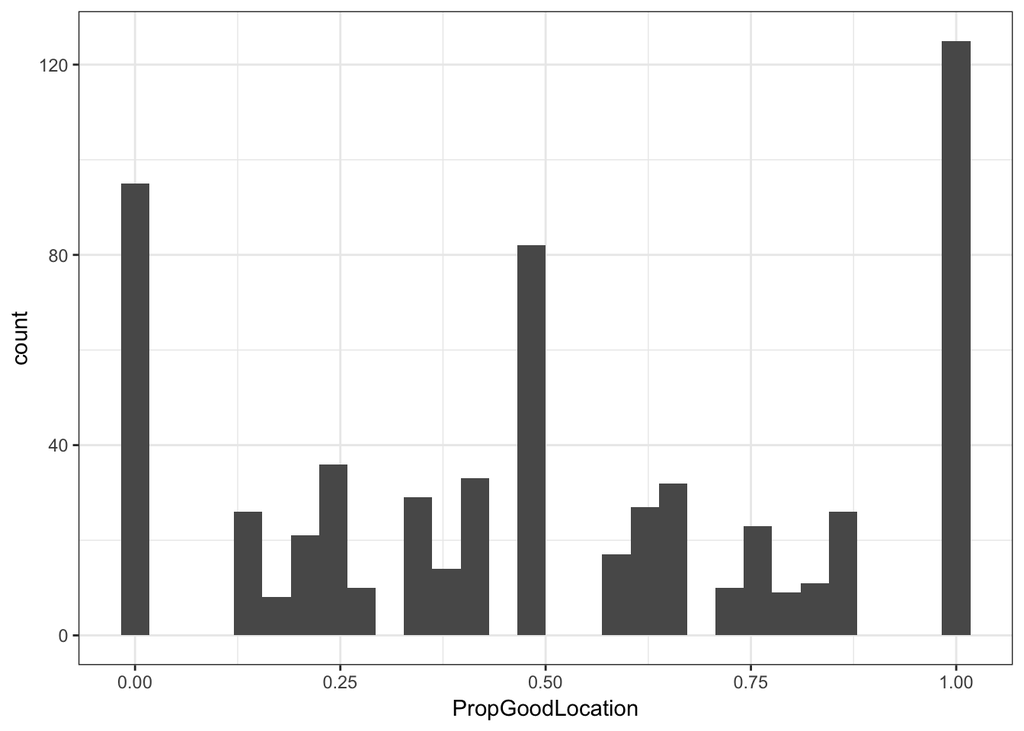

```r
dsub = d %>%
  filter(!d$SentenceOverlap)
ggplot(dsub, aes(x=PropGoodLocation)) +
  geom_histogram()
```

Is there a correlation between proportion of good location and number of BNB forms? Yes, a weak one.

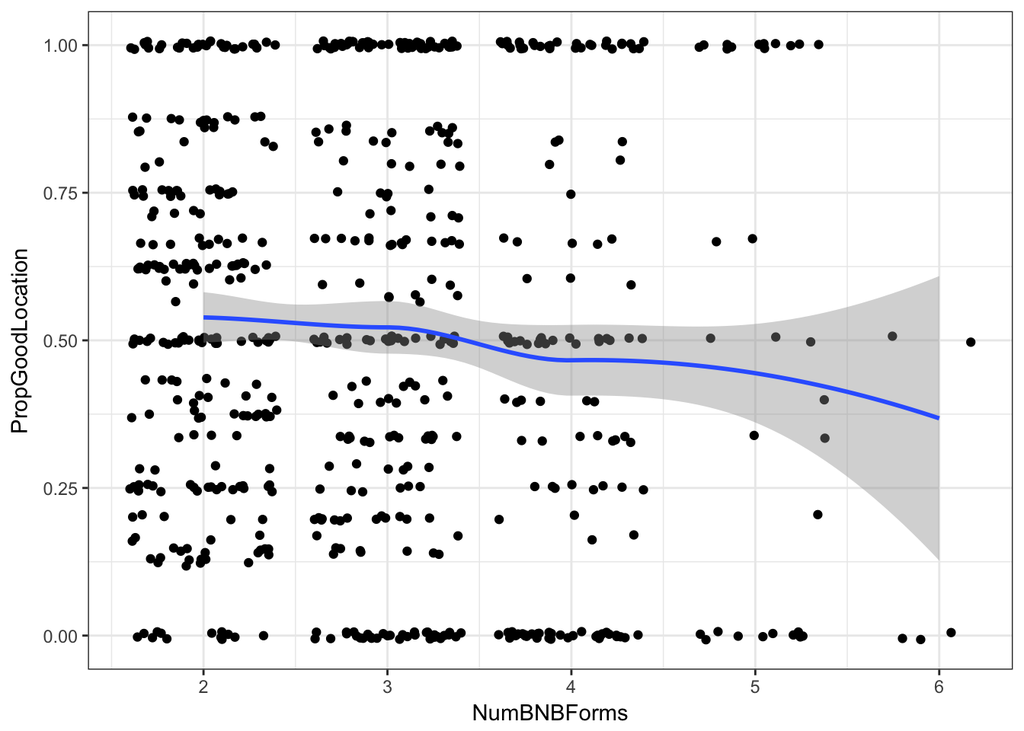

```r
ggplot(dsub, aes(x=NumBNBForms,y=PropGoodLocation)) +
  geom_jitter() +
  geom_smooth(method="loess")
```

```r
cor(dsub$NumBNBForms,dsub$PropGoodLocation)
```

```
## [1] -0.07712631
```

Is there a correlation between sentence length and both a) proportion of good location and b) number of BNB forms? Yes, a weak one.

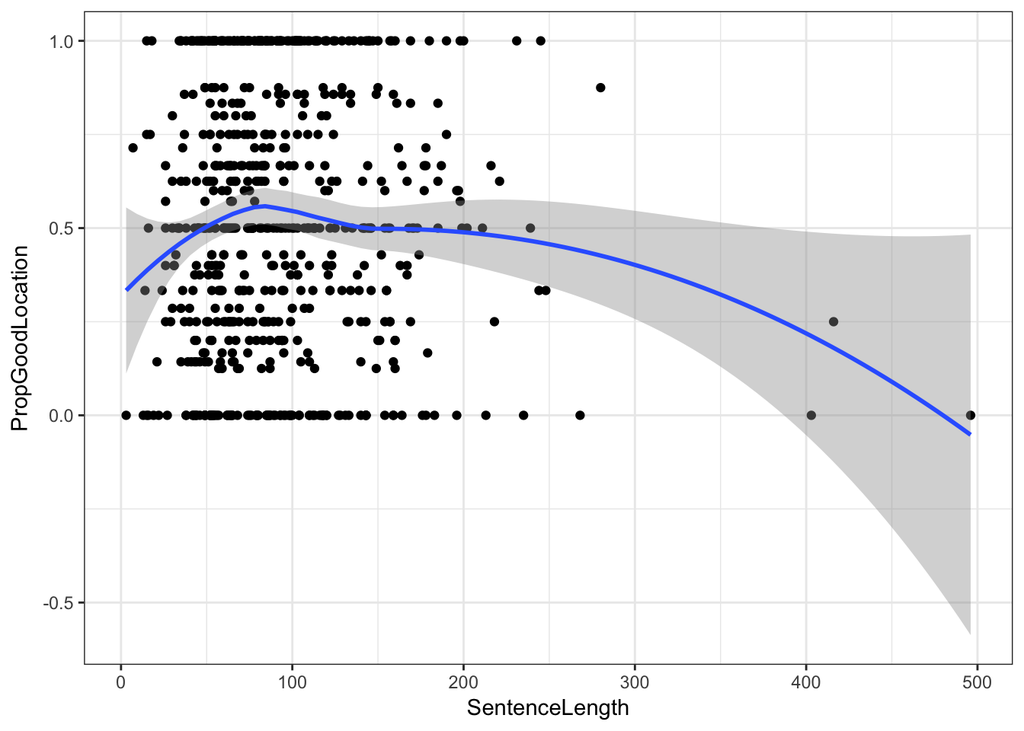

```r
ggplot(dsub, aes(x=SentenceLength,y=PropGoodLocation)) +
  geom_point() +
  geom_smooth(method="loess")
```

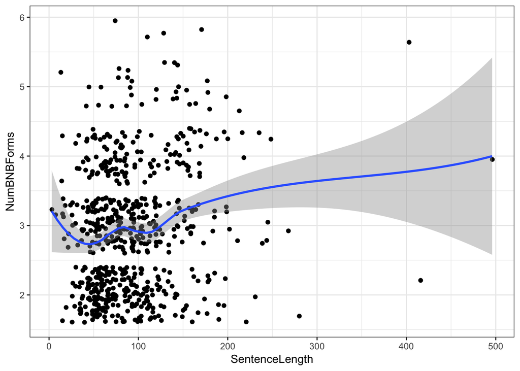

```r
ggplot(dsub, aes(x=SentenceLength,y=NumBNBForms)) +
  geom_jitter() +
  geom_smooth(method="loess")
```

Start by looking at the cases with large number of BNB forms – exlude?

```r
nrow(dsub[dsub$NumBNBForms > 4,])
```

```
## [1] 37
```

```r
kable(dsub[dsub$NumBNBForms > 4,c("ResponseModal","ResponseFreqGoodLocation","ResponsePropGoodLocation")])
```

|  | ResponseModal | ResponseFreqGoodLocation | ResponsePropGoodLocation |
| --- | --- | --- | --- |
| 32 | and, the first five minutes or ten minutes of the movie was, i was very well persuaded to walk out. very well persuaded but not both, | and, the first five minutes or ten minutes of the movie was, i was very well persuaded to walk out. very well persuaded but not both, | and, the first five minutes or ten minutes of the movie but not both was, i was very well persuaded to walk out. very well persuaded, \| and, the first five minutes or ten minutes but not both of the … |
| 52 | and i think that the people who are strongly in favor of the death penalty are really working from that gut level. uh, you know, whether it be a biblical force, uh, you know, the eye for an eye, a too… | and i think that the people who are strongly in favor of the death penalty are really working from that gut level. uh, you know, whether it be a biblical force, uh, you know, the eye for an eye, a too… | and i think that the people who are strongly in favor of the death penalty are really working from that gut level. uh, you know, whether it be a biblical force, uh, you know, the eye for an eye, a too… |
| 75 | i’m in favor of very little clean up, um, very little planning because we’ve got three or four couples that we get together with to play games but not both, | i’m in favor of very little clean up, um, very little planning because we’ve got three or four couples that we get together with to play games but not both, | i’m in favor of very little clean up, um, very little planning because we’ve got three or four couples but not both that we get together with to play games, |
| 78 | when if, if i have long periods of time, like christmas vacation, or, you know, when i know i’m not going to be doing anything for a while , um but not both, | when if, if i have long periods of time, like christmas vacation, or, you know, when i know i’m not going to be doing anything for a while , um but not both, | when if, if i have long periods of time, like christmas vacation, or, you know, when i know i’m not going to be doing anything but not both for a while , um, |
| 99 | if you live around the dallas area, you got five or six every weekend to choose from but not both . because they’re really into it. | if you live around the dallas area, you got five or six every weekend to choose from . because they’re really into it but not both. \| if you live around the dallas area, you got five or six but not b… | if you live around the dallas area, you got five or six every weekend but not both to choose from . because they’re really into it. \| if you live around the dallas area, you got five or six but not b… |
| 118 | and, well, uh, since now i’m in my mid-forties, when i was in grad school or when i was an undergraduate growing up in a more rural area i thought, you know, crime was, was reasonably unknown and just… | and, well, uh, since now i’m in my mid-forties, when i was in grad school or when i was an undergraduate growing up in a more rural area i thought, you know, crime was, was reasonably unknown and just… | and, well, uh, since now i’m in my mid-forties, when i was in grad school or when i was an undergraduate growing up in a more rural area i thought, you know, crime was, was reasonably unknown and just… |
| 147 | uh, and at the same time i think that i receive on, on the order of, uh, probably, seven or eight a week calls of the nature where one wishes that there were a convenient way to just hang up on it but… | uh, and at the same time i think that i receive on, on the order of, uh, probably, seven or eight a week calls of the nature where one wishes that there were a convenient way to just hang up on it but… | uh, and at the same time i think that i receive on, on the order of, uh, probably, seven or eight a week but not both calls of the nature where one wishes that there were a convenient way to just hang… |
| 164 | and he, uh, would like to just get a fifth wheel and just travel across the country and spend a month here or a couple of weeks there but not both, and just, you know, not, be settled anywhere, | and he, uh, would like to just get a fifth wheel and just travel across the country and spend a month here or a couple of weeks there but not both, and just, you know, not, be settled anywhere, | and he, uh, would like to just get a fifth wheel and just travel across the country and spend a month here or a couple of weeks there, and just, you but not both know, not, be settled anywhere, \| and… |
| 176 | um, some of the qualifications that i look for was that, uh, you know, the cost, and, um, exactly what they did , if it was structured or nonstructured, if they had a little academic, um, uh, in there… | um, some of the qualifications that i look for was that, uh, you know, the cost, and, um, exactly what they did , if it was structured or nonstructured, if they had a little academic, um, uh, in there… | um, some of the qualifications that i look for was that, uh, you know, the cost, and, um, exactly what they did , if it was structured or but not both nonstructured, if they had a little academic, um,… |
| 183 | also, also i have the observation of, uh, with the press is that, like any any stories that i had any first hand knowledge of that i see in the press, you know, which only happened like ten times in m… | also, also i have the observation of, uh, with the press is that, like any any stories that i had any first hand knowledge of that i see in the press, you know, which only happened like ten times in m… | also, also i have the observation of, uh, with the press is that, like any any stories that i had any first hand knowledge of that i see in the press, you know, which only happened like ten times in m… |
| 191 | perhaps that would be a solution if they were required to vote at least for their first three or four years but not both after they become of voting age. required to register and vote for four years, | perhaps that would be a solution if they were required to vote at least for their first three or four years but not both after they become of voting age. required to register and vote for four years, | perhaps that would be a solution if they were required to vote at least for their first three or four years after they become of voting age. required to register and vote but not both for four years, … |
| 207 | when i have heard about england’s elections , they are allowed to run for what, a total of six or eight weeks. but not both even for the higher offices in the, in the land. | when i have heard about england’s elections , they are allowed to run for what, a total of six or eight weeks. but not both even for the higher offices in the, in the land. \| when i have heard about … | when i have heard about england’s elections , they are allowed to run for what, a total of six or eight but not both weeks. even for the higher offices in the, in the land. |
| 218 | uh, and you can’t expect in a classroom for a particular course an hour a day to counteract, uh, sixteen or seventeen years but not both of influence at home. | uh, and you can’t expect in a classroom for a particular course an hour a day to counteract, uh, sixteen or seventeen years but not both of influence at home. \| uh, and you can’t expect in a classroo… | uh, and you can’t expect in a classroom for a particular course an hour a day to counteract, uh, sixteen or seventeen years of but not both influence at home. \| uh, and you can’t expect in a classroo… |
| 232 | and, and, but of course most time, most of the time management has a hard time distributing or getting the word out to the people who must know but not both. | and, and, but of course most time, most of the time management has a hard time distributing or getting the word out but not both to the people who must know. \| and, and, but of course most time, most… | and, and, but of course most time, most of the time management has a hard time distributing or getting the word but not both out to the people who must know. |
| 242 | of course, if he’s fallen in love with drugs and there isn’t anything but getting stoned or high but not both is, is the only thing in life that seems to be meaningful, then maybe there is no hope. | of course, if he’s fallen in love with drugs and there isn’t anything but getting stoned or high but not both is, is the only thing in life that seems to be meaningful, then maybe there is no hope. | of course, if he’s fallen in love with drugs and there isn’t anything but getting stoned or high is, is the only thing in life that seems to be meaningful, then but not both maybe there is no hope. |
| 244 | but if they’re going to offer these services, or these recorded message, everything, they ought to be stuck working with the phone book like everybody else instead of using a computer to go through an… | but if they’re going to offer these services, or these recorded message, everything, they ought to be stuck working with the phone book like everybody else instead of using a computer to go through an… | but if they’re going to offer these services, or these recorded message, everything, they ought to be stuck working with the phone book like everybody else instead of using a computer but not both to … |
| 272 | we use it more for just writing programs when we need to or, um, doing research, looking at the speech signal and then doing writing but not both, and also as a just as a terminal, \| we use it more f… | we use it more for just writing programs when we need to or, um, doing research, looking at the speech signal and then doing writing but not both, and also as a just as a terminal, \| we use it more f… | we use it more for just writing programs when we need to or, um, doing research, looking at the speech signal but not both and then doing writing, and also as a just as a terminal, \| we use it more f… |
| 298 | but, um, in many, many cases whether or not an individual has a problem with drugs, it’s not even going to effect anybody but his, uh, you know, himself and his own family but not both, perhaps, um, d… | but, um, in many, many cases whether or not an individual has a problem with drugs, it’s not even going to effect anybody but his, uh, you know, himself and his own family but not both, perhaps, um, d… | but, um, in many, many cases whether or not an individual has a problem with drugs, it’s not even going to effect anybody but his, uh, you know, himself and his own family, perhaps, um but not both, d… |
| 322 | but, um, they have about four or five different prices now but not both, that they’re structuring it with , | but, um, they have about four or five but not both different prices now, that they’re structuring it with , \| but, um, they have about four or five different prices now but not both, that they’re str… | but, um, they have about four or five different prices but not both now, that they’re structuring it with , |
| 327 | they’re worse than american cars i think or just as bad as far as resale goes but not both. | they’re worse than american cars i think or just as bad as far as resale goes but not both. | they’re worse than american cars i think or just but not both as bad as far as resale goes. \| they’re worse than american cars i think or just as bad but not both as far as resale goes. |
| 381 | i said if i knew beyond a doubt or if i felt beyond a doubt that he had done it, yeah, i guess i could convict him but not both, | i said if i knew beyond a doubt or if i felt beyond a doubt but not both that he had done it, yeah, i guess i could convict him, \| i said if i knew beyond a doubt or if i felt beyond a doubt that he … | i said if i knew beyond a doubt or if i felt beyond a doubt but not both that he had done it, yeah, i guess i could convict him, \| i said if i knew beyond a doubt or if i felt beyond a doubt that he … |
| 407 | and, i’ve come to the conclusion, and this is a pretty scary thought to me, even, that if a guy is convicted , or a gal is convicted but not both , of a crime, rather than put them in prison, because … | and, i’ve come to the conclusion, and this is a pretty scary thought to me, even, that if a guy is convicted , or a gal is convicted but not both , of a crime, rather than put them in prison, because … | and, i’ve come to the conclusion, and this is a pretty scary thought to me, even, that if a guy is convicted , or a gal is convicted , of a crime but not both, rather than put them in prison, because … |
| 454 | i’ve, i’ve kind of formed the attitude that, you know, if i could just, if i could pick two or three shots but not both out, uh, out of my game every time and put them together on one hole, then i do … | i’ve, i’ve kind of formed the attitude that, you know, if i could just, if i could pick two or three shots but not both out, uh, out of my game every time and put them together on one hole, then i do … | i’ve, i’ve kind of formed the attitude that, you know, if i could just, if i could pick two or three shots out, uh, out of my game every time and put them together on one hole, then i do pretty but no… |
| 490 | in, in colorado when the broncos went to the superbowl three times in the last, i don’t know, five or six years whatever it’s been but not both . um, they have these songs on the radio. \| in, in colo… | in, in colorado when the broncos went to the superbowl three times in the last, i don’t know, five or six years whatever it’s been . um, they have these songs on the radio but not both. | in, in colorado when the broncos went to the superbowl three times in the last, i don’t know, five or six years whatever it’s been but not both . um, they have these songs on the radio. \| in, in colo… |
| 496 | when we moved from louisiana to denver , it was astounding, you know, to find that prices were, oh, i guess almost two or three times as high as we’d expected but not both. | when we moved from louisiana to denver , it was astounding, you know, to find that prices were, oh, i guess almost two or three times as high as we’d expected but not both. | when we moved from louisiana to denver , it was astounding, you know, to find that prices were, oh, i guess almost two or three times as high but not both as we’d expected. \| when we moved from louis… |
| 504 | but, while they were there they set back, drank about four or five cups of coffee apiece and made snowmen on the hoods of their vehicles threw snowballs all over the place, had themselves a ball for a… | but, while they were there they set back, drank about four or five cups of coffee apiece and made snowmen on the hoods of their vehicles threw snowballs all over the place, had themselves a ball for a… | but, while they were there they set back, drank about four or five cups of coffee but not both apiece and made snowmen on the hoods of their vehicles threw snowballs all over the place, had themselves… |
| 505 | uh, and your very best teachers in my estimation should be first, second or third grade. but not both so that the children develop good learning patterns | uh, and your very best teachers in my estimation should be first, second or third grade. but not both so that the children develop good learning patterns | uh, and your very best teachers in my estimation should be first, second or third grade. so that the children develop good but not both learning patterns |
| 540 | i had, i’ve had, uh, two or three drug tests that i had to get before i could start working at a job uh, different jobs but not both. | i had, i’ve had, uh, two or three drug tests that i had to get before i could start working at a job uh, different jobs but not both. | i had, i’ve had, uh, two or three drug tests that i had to get before i could start but not both working at a job uh, different jobs. |
| 541 | in this country, and for example with alcohol or with drugs but not both is, we don’t seem to understand how to handle it as a society to say okay, it is okay under these circumstances, but if you ste… | in this country, and for example with alcohol or with drugs is, we don’t seem to understand how to handle it as a society to say okay, it is okay under these circumstances, but if you step outside the… | in this country, and for example with alcohol or with drugs is, we don’t seem to understand how to handle it as a society but not both to say okay, it is okay under these circumstances, but if you ste… |
| 546 | two or three years but not both in with them you can start buying stock \| two or three years in with them you can start buying stock but not both. | two or three years in with them you can start buying stock but not both. | two or three years in with them but not both you can start buying stock |
| 561 | it’s burned so completely, that you don’t have any, uh, nitrous oxides, uh, or oxides of nitrogen but not both, uh, to, uh, form because of, by virtue of the very combustion process of the diesel engi… | it’s burned so completely, that you don’t have any, uh, nitrous oxides, uh, or oxides of nitrogen, uh, to, uh, form because of, by virtue of the very combustion process of the diesel engine, because d… | it’s burned so completely, that you don’t have any, uh, nitrous oxides, uh, or oxides of nitrogen, uh, to, uh, form because of, by virtue of the very combustion process of the diesel engine, because d… |
| 601 | uh, i don’t remember what they call it , sort of like a positive, negatives or but not both some, some kind of word they use when a, uh, you get a, uh, a positive indication of drugs , but there’s not… | uh, i don’t remember what they call it , sort of like a positive, negatives or some, some kind of word they use but not both when a, uh, you get a, uh, a positive indication of drugs , but there’s not… | uh, i don’t remember what they call it , sort of like a positive, negatives or some, some kind of word they use but not both when a, uh, you get a, uh, a positive indication of drugs , but there’s not… |
| 607 | it’s probably a japanese or a burmese company but not both owning and hiring people in the u s. | it’s probably a japanese or a burmese company but not both owning and hiring people in the u s. | it’s probably a japanese or a burmese but not both company owning and hiring people in the u s. \| it’s probably a japanese or a burmese company but not both owning and hiring people in the u s. \| it… |
| 609 | i think i’ve actually seen a number of star treks, one way or another over the years. uh, although i never watched it regularly but not both. | i think i’ve actually seen a number of star treks, one way or another over the years. uh, although i never watched it regularly but not both. | i think i’ve actually seen a number of star treks, one way or another over the years. uh but not both, although i never watched it regularly. |
| 611 | whatever you ask or scream but not both when i’m on the phone , the answer is no. | whatever you ask or scream but not both when i’m on the phone , the answer is no. \| whatever you ask or scream when i’m on the phone but not both , the answer is no. | whatever you ask or but not both scream when i’m on the phone , the answer is no. \| whatever you ask or scream when i’m on the phone , the but not both answer is no. |
| 613 | because if you have two or three kids but not both, by the, e-, way the inflation’s going i think a woman’s always going to have to work | because if you have two or three kids but not both, by the, e-, way the inflation’s going i think a woman’s always going to have to work | because if you have two or but not both three kids, by the, e-, way the inflation’s going i think a woman’s always going to have to work |
| 621 | and she would sit like on my neck or my shoulder while i was working, and things like that. yeah, much more than you would think but not both. | and she would sit like on my neck or my shoulder while i was working, and things like that. yeah, much more than you would think but not both. | and she would sit like on my neck or my shoulder but not both while i was working, and things like that. yeah, much more than you would think. \| and she would sit like on my neck or my shoulder while… |

```r
kable(arrange(d[c("NumBNBForms","ResponseModal","ResponseFreqGoodLocation","ResponsePropGoodLocation","BNCClosestToOr")],NumBNBForms))
```

| NumBNBForms | ResponseModal | ResponseFreqGoodLocation | ResponsePropGoodLocation | BNCClosestToOr |
| --- | --- | --- | --- | --- |
| 1 | you know, i don’t know for, if you’re familiar with that or not but not both. | you know, i don’t know for, if you’re familiar with that or not but not both. | you know, i don’t know for, if you’re familiar with that or not but not both. | NA |
| 1 | do you think that’s why most rock stars nowadays keep their marriages secret , or at least they keep it quiet but not both . | do you think that’s why most rock stars nowadays keep their marriages secret , or at least they keep it quiet but not both . | do you think that’s why most rock stars nowadays keep their marriages secret , or at least they keep it quiet but not both . | NA |
| 1 | but i’m not sure if if it’s if you get caught or if you turn yourself in but not both. | but i’m not sure if if it’s if you get caught or if you turn yourself in but not both. | but i’m not sure if if it’s if you get caught or if you turn yourself in but not both. | NA |
| 1 | what is happening at least in this state and i expect to see it in other states very soon, legislation been introduced as that, if a citizen of the state, being, myself, has not committed a felony and… | what is happening at least in this state and i expect to see it in other states very soon, legislation been introduced as that, if a citizen of the state, being, myself, has not committed a felony and… | what is happening at least in this state and i expect to see it in other states very soon, legislation been introduced as that, if a citizen of the state, being, myself, has not committed a felony and… | NA |
| 1 | well, we just started two or three weeks ago but not both. | well, we just started two or three weeks ago but not both. | well, we just started two or three weeks ago but not both. | NA |
| 1 | i’ve done that once or twice but not both. | i’ve done that once or twice but not both. | i’ve done that once or twice but not both. | NA |
| 1 | after that, if you asked me that i wouldn’t have been able to tell you if that was football or baseball but not both. | after that, if you asked me that i wouldn’t have been able to tell you if that was football or baseball but not both. | after that, if you asked me that i wouldn’t have been able to tell you if that was football or baseball but not both. | NA |
| 1 | and i told my husband , i said , you know, it’s either me or the dog but not both, | and i told my husband , i said , you know, it’s either me or the dog but not both, | and i told my husband , i said , you know, it’s either me or the dog but not both, | NA |
| 1 | i tried it like once or twice but not both. | i tried it like once or twice but not both. | i tried it like once or twice but not both. | NA |
| 1 | has that been the cutlass or the sierra but not both. | has that been the cutlass or the sierra but not both. | has that been the cutlass or the sierra but not both. | NA |
| 1 | now, my kids didn’t like it because they just wanted to get plain old spaghetti or lasagna but not both, | now, my kids didn’t like it because they just wanted to get plain old spaghetti or lasagna but not both, | now, my kids didn’t like it because they just wanted to get plain old spaghetti or lasagna but not both, | NA |
| 1 | well, um, with credit cards is, me, i, uh, i try to get maybe just one or two but not both, | well, um, with credit cards is, me, i, uh, i try to get maybe just one or two but not both, | well, um, with credit cards is, me, i, uh, i try to get maybe just one or two but not both, | NA |
| 1 | i think it’s, four or five but not both, | i think it’s, four or five but not both, | i think it’s, four or five but not both, | NA |
| 1 | they don’t have the offense to, uh, to get out, or to have the, the more runs but not both , | they don’t have the offense to, uh, to get out, or to have the, the more runs but not both , | they don’t have the offense to, uh, to get out, or to have the, the more runs but not both , | NA |
| 1 | uh, uh, i really think that we need to get into the mold where we talk about years rather than months or weeks but not both . | uh, uh, i really think that we need to get into the mold where we talk about years rather than months or weeks but not both . | uh, uh, i really think that we need to get into the mold where we talk about years rather than months or weeks but not both . | NA |
| 1 | and basically, uh, we were going to be paying seventy or eighty percent tax but not both. | and basically, uh, we were going to be paying seventy or eighty percent tax but not both. | and basically, uh, we were going to be paying seventy or eighty percent tax but not both. | NA |
| 1 | and finally president johnson said, well, they’re weren’t really sure whether it was a dolphin or a torpedo but not both. | and finally president johnson said, well, they’re weren’t really sure whether it was a dolphin or a torpedo but not both. | and finally president johnson said, well, they’re weren’t really sure whether it was a dolphin or a torpedo but not both. | NA |
| 1 | we used to get four or five inches a year but not both. | we used to get four or five inches a year but not both. | we used to get four or five inches a year but not both. | NA |
| 1 | i think my wife is much better than i am at that walking into a place and getting a feeling for whether it is a loving and caring place or not but not both. | i think my wife is much better than i am at that walking into a place and getting a feeling for whether it is a loving and caring place or not but not both. | i think my wife is much better than i am at that walking into a place and getting a feeling for whether it is a loving and caring place or not but not both. | NA |
| 1 | and my husband and i like getting the salads or the lighter meals but not both. | and my husband and i like getting the salads or the lighter meals but not both. | and my husband and i like getting the salads or the lighter meals but not both. | NA |
| 1 | but, uh, uh, i don’t know if it’s their proposal or one that ’s being seriously kicked around but not both. | but, uh, uh, i don’t know if it’s their proposal or one that ’s being seriously kicked around but not both. | but, uh, uh, i don’t know if it’s their proposal or one that ’s being seriously kicked around but not both. | NA |
| 1 | and so when i’m teaching a class , obviously i wear a suit or dress but not both, | and so when i’m teaching a class , obviously i wear a suit or dress but not both, | and so when i’m teaching a class , obviously i wear a suit or dress but not both, | NA |
| 1 | well, i don’t know if i know anything or not but not both, | well, i don’t know if i know anything or not but not both, | well, i don’t know if i know anything or not but not both, | NA |
| 1 | she’s about seven or eight years old but not both. | she’s about seven or eight years old but not both. | she’s about seven or eight years old but not both. | NA |
| 1 | and, and, um, uh, the landscape is much different here in texas than it is, you know, in the north. um, or even where you are but not both . | and, and, um, uh, the landscape is much different here in texas than it is, you know, in the north. um, or even where you are but not both . | and, and, um, uh, the landscape is much different here in texas than it is, you know, in the north. um, or even where you are but not both . | NA |
| 1 | i’m, i’m usually in the eighties or nineties but not both. | i’m, i’m usually in the eighties or nineties but not both. | i’m, i’m usually in the eighties or nineties but not both. | NA |
| 1 | and, uh, many matters are so complicated that it ’s so hard to, uh, come up with the fair value, uh, or the fair sentence but not both. | and, uh, many matters are so complicated that it ’s so hard to, uh, come up with the fair value, uh, or the fair sentence but not both. | and, uh, many matters are so complicated that it ’s so hard to, uh, come up with the fair value, uh, or the fair sentence but not both. | NA |
| 1 | and you got a nickel or dime but not both, which in that time was a lot of money, when you returned them . | and you got a nickel or dime but not both, which in that time was a lot of money, when you returned them . | and you got a nickel or dime but not both, which in that time was a lot of money, when you returned them . | NA |
| 1 | and the federal came in and said, hey, you know, you have either got to build more prisons or let people go but not both. | and the federal came in and said, hey, you know, you have either got to build more prisons or let people go but not both. | and the federal came in and said, hey, you know, you have either got to build more prisons or let people go but not both. | NA |
| 1 | if you want to play tennis, or racquetball but not both, | if you want to play tennis, or racquetball but not both, | if you want to play tennis, or racquetball but not both, | NA |

[output cut: 1214 more lines]

### NExt steps

Before using above selection criteria, Neele will generate new “best response” column that is result of choosing the case where “but not both” is closest to “or” but doesn’t come right after it. Then we do the above comparison again.